# How to plot Pressure and Wind

## How to plot Pressure and Wind

- Run the cell below before running any other cell.Cell is commented. Uncomment it first before running it.
- Then restart the kernel and run other cell
- Keep in mind to perform these procedures each time you open this notebook.

```python
# !apt-get install -qq libgdal-dev libproj-dev
# #!pip install --no-binary shapely shapely
# !pip install --no-binary shapely shapely --force
# !pip install cartopy
```

```python
import xarray as xr
from datetime import datetime, timedelta
import numpy as np
import pandas as pd
import warnings
warnings.filterwarnings("ignore")
```

```python
import cartopy
import cartopy.crs as ccrs
import cartopy.feature as cfeature
import matplotlib.pyplot as plt
```

## About Data Download

Now we will use data from **"ERA5 hourly data on single levels from 1940 to present"** that is availble for free in climate data store website: **[cds.climate.copernicus.eu](https://cds.climate.copernicus.eu/#!/home)**

The data I downloaded has the following specifications:

```
Product type:
Reanalysis

Variable:
100m_u_component_of_wind,
100m_v_component_of_wind,
10m_u_component_of_wind,
10m_v_component_of_wind,
surface_pressure

Year:2023

Month:June, July

Day:
01, 02, 03, 04, 05, 06, 07, 08, 09, 10, 11, 12, 13, 14, 15, 16, 17, 18, 19, 20, 21, 22, 23, 24, 25, 26, 27, 28, 29, 30, 31

Time:
00:00, 01:00, 02:00, 03:00, 04:00, 05:00, 06:00, 07:00, 08:00, 09:00, 10:00, 11:00, 12:00, 13:00, 14:00, 15:00, 16:00, 17:00, 18:00, 19:00, 20:00, 21:00, 22:00, 23:00

Sub-region extraction:
North 29°, West 85°, South 18°, East 97°

Format:
NetCDF (experimental)
```

**We can download the data directly using API. we need to follow the setps below to download the data**:

#### Install the CDS API: Run the snippet below

```python
!pip install cdsapi
```

#### Run the the snippet below to download the data:

**Don't forget to change the `output_folder` location as you desire.**

```python
import cdsapi
import os

c = cdsapi.Client()
output_folder= '/mnt/102ECBA62ECB8368/Academic journey/ML_HEATWAVE/Data/Test/'
#Ensure theoutput folder exists
os.makedirs(output_folder,exist_ok=True)


c.retrieve(
    'reanalysis-era5-single-levels',
    {
        'product_type': 'reanalysis',
        'format': 'netcdf',
        'variable': [
            '100m_u_component_of_wind', '100m_v_component_of_wind', '10m_u_component_of_wind',
            '10m_v_component_of_wind', 'surface_pressure',
        ],
        'year': '2023',
        'month': [
            '06', '07',
        ],
        'day': [
            '01', '02', '03',
            '04', '05', '06',
            '07', '08', '09',
            '10', '11', '12',
            '13', '14', '15',
            '16', '17', '18',
            '19', '20', '21',
            '22', '23', '24',
            '25', '26', '27',
            '28', '29', '30',
            '31',
        ],
        'time': [
            '00:00', '01:00', '02:00',
            '03:00', '04:00', '05:00',
            '06:00', '07:00', '08:00',
            '09:00', '10:00', '11:00',
            '12:00', '13:00', '14:00',
            '15:00', '16:00', '17:00',
            '18:00', '19:00', '20:00',
            '21:00', '22:00', '23:00',
        ],
        'area': [
            29, 85, 18,
            97,
        ],
    },
    os.path.join(output_folder,'sp_u_v.nc')
)
```

```python
data_path='/mnt/102ECBA62ECB8368/Academic journey/ML_HEATWAVE/Data/Test/sp_u_v.nc'
ds=xr.open_dataset(data_path)
```

```python
ds
```

```
<xarray.Dataset>
Dimensions:    (longitude: 49, latitude: 45, expver: 2, time: 1464)
Coordinates:
  * longitude  (longitude) float32 85.0 85.25 85.5 85.75 ... 96.5 96.75 97.0
  * latitude   (latitude) float32 29.0 28.75 28.5 28.25 ... 18.5 18.25 18.0
  * expver     (expver) int32 1 5
  * time       (time) datetime64[ns] 2023-06-01 ... 2023-07-31T23:00:00
Data variables:
    u100       (time, expver, latitude, longitude) float32 ...
    v100       (time, expver, latitude, longitude) float32 ...
    u10        (time, expver, latitude, longitude) float32 ...
    v10        (time, expver, latitude, longitude) float32 ...
    sp         (time, expver, latitude, longitude) float32 ...
Attributes:
    Conventions:  CF-1.6
    history:      2023-08-30 09:14:50 GMT by grib_to_netcdf-2.25.1: /opt/ecmw...
```

expver = 1 means ERA5 and expver = 5 means ERA5T.  
Google to understand more.

### Check the dimensions

```python
ds.sp.dims
```

```
('time', 'expver', 'latitude', 'longitude')
```

Here we will use just **`era5(expver=1)`** data and we will use data for **`time = 2023-06-15T12:00:00`**

```python
expver_slice=1
desired_time = '2023-06-15T12:00:00'
surface_pressure = ds.sel(expver=expver_slice,time=desired_time)
```

```python
surface_pressure
```

```
<xarray.Dataset>
Dimensions:    (longitude: 49, latitude: 45)
Coordinates:
  * longitude  (longitude) float32 85.0 85.25 85.5 85.75 ... 96.5 96.75 97.0
  * latitude   (latitude) float32 29.0 28.75 28.5 28.25 ... 18.5 18.25 18.0
    expver     int32 1
    time       datetime64[ns] 2023-06-15T12:00:00
Data variables:
    u100       (latitude, longitude) float32 ...
    v100       (latitude, longitude) float32 ...
    u10        (latitude, longitude) float32 ...
    v10        (latitude, longitude) float32 ...
    sp         (latitude, longitude) float32 ...
Attributes:
    Conventions:  CF-1.6
    history:      2023-08-30 09:14:50 GMT by grib_to_netcdf-2.25.1: /opt/ecmw...
```

Now we have data for 12PM,June 15,2023. We can plot this data in two ways

- Directly from the data
- Creating a dataframe and plotting

### Plotting Directly from data

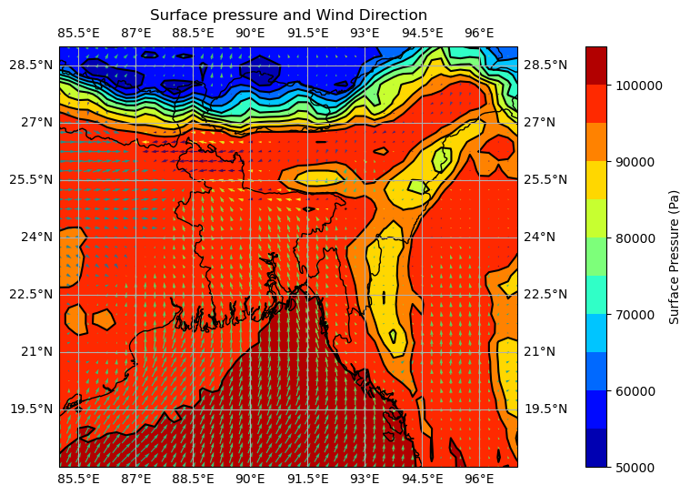

```python
from matplotlib.cm import get_cmap
warnings.filterwarnings("ignore")


# Get latitude and longitude from xarray.Dataset
latitude = surface_pressure['latitude'].values
longitude = surface_pressure['longitude'].values

# Get sp,u10 and v10 from xarray.Dataset
pressure_data = surface_pressure.sp
u10_data = surface_pressure.u10
v10_data = surface_pressure.v10


# Calculate wind speed and direction
wind_speed = np.sqrt(u10_data**2 + v10_data**2)
wind_direction = np.arctan2(v10_data, u10_data) * (180 / np.pi)

# Create a Cartopy PlateCarree projection
projection = ccrs.PlateCarree()

# Create a figure and axis
fig, ax = plt.subplots(subplot_kw={'projection': projection}, figsize=(12, 6))

# Plot surface pressure using contourf
contourf = ax.contourf(longitude, latitude, pressure_data, levels=10, cmap=get_cmap("jet"),transform=projection)
# Plot isobar lines using contour
contour = ax.contour(longitude, latitude, pressure_data, levels=10, colors='black', transform=projection)
# Plot wind direction using quiver
quiver = ax.quiver(longitude, latitude, u10_data, v10_data, wind_direction, transform=projection, pivot='middle', color='black')

# Add colorbar
cbar = plt.colorbar(contourf, ax=ax, orientation='vertical', pad=0.08, label='Surface Pressure (Pa)')

# Set title and labels
ax.set_title('Surface pressure and Wind Direction')
ax.set_xlabel('Longitude')
ax.set_ylabel('Latitude')

# Add coastlines and gridlines
ax.coastlines()
ax.add_feature(cfeature.BORDERS)
ax.gridlines(draw_labels=True)

# Show the plot
plt.show()
```

### Creating a dataframe and plotting

```python
import pandas as pd
import numpy as np

sp=np.array(surface_pressure.sp)
u10=np.array(surface_pressure.u10)
v10=np.array(surface_pressure.v10)
latitude=surface_pressure['latitude'].values
longitude=surface_pressure['longitude'].values

reshaped_sp=sp.reshape(-1)
reshaped_u10=u10.reshape(-1)
reshaped_v10=v10.reshape(-1)

df = pd.DataFrame({
    'latitude': np.repeat(latitude, len(longitude)),
    'longitude': np.tile(longitude, len(latitude)),
    'sp': reshaped_sp,
    'u10': reshaped_u10,
    'v10': reshaped_v10
})
```

```python
df
```

|  | latitude | longitude | sp | u10 | v10 |
| --- | --- | --- | --- | --- | --- |
| 0 | 29.0 | 85.00 | 55012.375000 | 1.191241 | 2.434555 |
| 1 | 29.0 | 85.25 | 55506.203125 | 0.671841 | 2.844354 |
| 2 | 29.0 | 85.50 | 55982.367188 | 1.374785 | 3.435182 |
| 3 | 29.0 | 85.75 | 55993.121094 | 1.822113 | 3.359084 |
| 4 | 29.0 | 86.00 | 55572.250000 | 1.975387 | 3.388389 |
| ... | ... | ... | ... | ... | ... |
| 2200 | 18.0 | 96.00 | 98998.460938 | -0.711945 | 1.409822 |
| 2201 | 18.0 | 96.25 | 98463.156250 | -0.703296 | 1.740213 |
| 2202 | 18.0 | 96.50 | 99822.531250 | -0.901735 | 2.133469 |
| 2203 | 18.0 | 96.75 | 100176.578125 | -1.093928 | 2.037045 |
| 2204 | 18.0 | 97.00 | 96870.312500 | -0.548101 | 1.441017 |

2205 rows × 5 columns

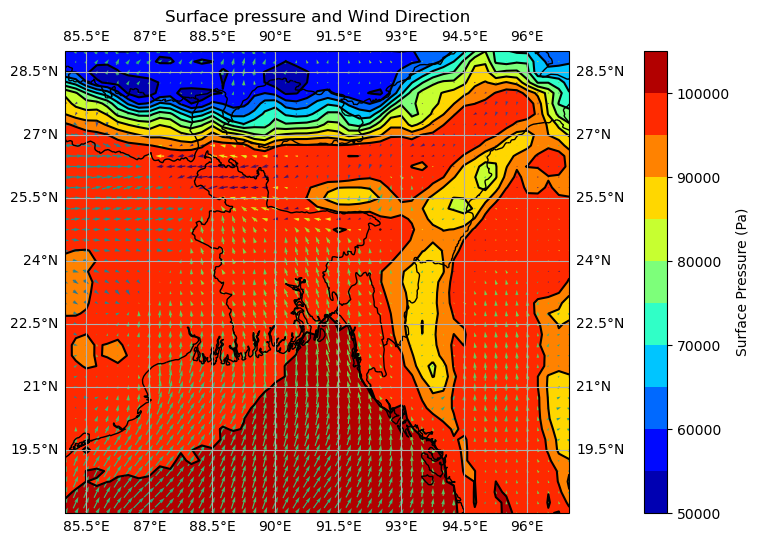

```python
# Get the latitude and longitude values
latitude=df['latitude'].unique()
longitude=df['longitude'].unique()
# Reshape the sp,u10,v10 data into a 2D array matching the grid
sp_array=df['sp'].values.reshape(len(latitude),len(longitude))
u10_array=df['u10'].values.reshape(len(latitude),len(longitude))
v10_array=df['v10'].values.reshape(len(latitude),len(longitude))

# Create a Cartopy PlateCarree projection
projection = ccrs.PlateCarree()

# Create a figure and axis
fig, ax = plt.subplots(subplot_kw={'projection': projection}, figsize=(12, 6))

# Plot wind speed using contourf
contourf = ax.contourf(longitude, latitude, sp_array, levels=10, cmap=get_cmap("jet"),transform=projection)

# Plot isobar lines using contour
contour = ax.contour(longitude, latitude, sp_array, levels=10, colors='black', transform=projection)

# Plot wind direction using quiver
quiver = ax.quiver(longitude, latitude, u10_array, v10_array, wind_direction, transform=projection, pivot='middle', color='black')

# Add colorbar
cbar = plt.colorbar(contourf, ax=ax, orientation='vertical', pad=0.08, label='Surface Pressure (Pa)')

# Set title and labels
ax.set_title('Surface pressure and Wind Direction')
ax.set_xlabel('Longitude')
ax.set_ylabel('Latitude')


# Add coastlines and gridlines
ax.coastlines()
ax.add_feature(cfeature.BORDERS)
ax.gridlines(draw_labels=True)

# Show the plot
plt.show()
```